# Observatoire statistique — rapport final

Démonstrateur personnel indépendant de l’UPEC — données entièrement synthétiques

## 1 Résumé exécutif

**Ce rapport ne décrit pas l’UPEC réelle.** Il présente un démonstrateur personnel utilisant exclusivement des données fictives, gelées au 2026-09-30. Sa finalité est d’illustrer une chaîne de production d’indicateurs universitaires contrôlés, reproductibles et accessibles aux responsables de formation.

La base couvre **15 000 étudiants distincts** et **31 816 inscriptions** sur trois années universitaires. Après traitement des anomalies contrôlées, les 209 règles de qualité ne relèvent plus d’alerte. Les 10 indicateurs prioritaires sont déclinés en 33 lignes conservant leurs populations et leurs millésimes.

Les enquêtes nécessitent une lecture conjointe de la participation et de la satisfaction. Les parcours nécessitent des horizons comparables. Le modèle exploratoire discrimine faiblement les réussites sur le jeu de test (AUC : 0,593). Ces résultats synthétiques servent à tester les outils ; ils ne fondent aucune décision concernant des étudiants ou des formations réels.

## 2 Contexte et objectifs

Le projet s’inspire des missions d’un observatoire universitaire : caractériser les inscriptions, suivre la réussite et les parcours, exploiter les enquêtes, étudier le devenir des diplômés et préparer des restitutions de pilotage. La question directrice est : comment articuler données de scolarité et enquêtes pour éclairer l’offre de formation avec des indicateurs définis et traçables ?

Les livrables comprennent les scripts R, les notebooks pédagogiques, les dictionnaires, les contrôles qualité, un pipeline `targets`, les exports contrôlés, un tableau de bord Shiny et un projet Power BI. Les cinq pages des tableaux de bord couvrent inscriptions, réussite, parcours, enquêtes et insertion. Les interfaces exposent les résultats et les filtres accessibles sans demander à l’utilisateur de maîtriser les méthodes statistiques.

## 3 Données et périmètre

Les années couvertes sont 2023-2024, 2024-2025 et 2025-2026. Les tables relient étudiants, formations, inscriptions, résultats, parcours, invitations et réponses aux évaluations, décisions de diplôme, diplômes et devenir des diplômés. L’identifiant étudiant reste stable ; les inscriptions annuelles constituent une unité distincte des personnes suivies sur toute la période.

Le générateur et ses graines sont documentés dans `config/simulation.R` et `R/data/simulate_data.R`. Les relations statistiques sont choisies pour leur plausibilité pédagogique. Elles ne reproduisent pas les distributions d’un établissement réel. Une variante contenant des anomalies est conservée séparément.

Population annuelle et inscriptions synthétiques

| Année | Inscriptions | Étudiants | Évolution (%) |
| --- | --- | --- | --- |
| 2023-2024 | 11000 | 11000 | Non disponible |
| 2024-2025 | 10633 | 10633 | -3.34 |
| 2025-2026 | 10183 | 10183 | -4.23 |

Les données originales restent dans `data/raw/`, les tables analytiques dans `data/processed/`. Le calcul consommé ici provient de la reconstruction isolée dans `outputs/pipeline_rapport/`, sans écraser ces données originales.

## 4 Qualité et traçabilité

Les contrôles portent sur les dimensions, les clés, les types, les domaines, l’intégrité référentielle, les ECTS, les dates et la cohérence longitudinale. Le nettoyage s’appuie sur le journal des anomalies injectées ; cette possibilité de retrouver la vérité simulée ne serait pas disponible sur une base réelle.

Contrôles avant et après traitement des anomalies

| Etape | Regles | Alertes | Verdict |
| --- | --- | --- | --- |
| Avant nettoyage | 209 | 127 | non_conforme |
| Après nettoyage | 209 | 0 | conforme |

Un événement peut déclencher plusieurs alertes : le nombre d’alertes ne correspond pas au nombre d’anomalies injectées. Les valeurs manquantes légitimes ne sont pas automatiquement imputées. La non-réponse et les observations hors fenêtre restent identifiables.

Avant le rendu, le lecteur vérifie le dernier statut de calcul, les empreintes MD5 des six produits exportés et celles des sources, ainsi que le verdict qualité. Un échec ou une modification de source provoque l’arrêt du rapport. Les empreintes servent à détecter les changements de fichiers ; elles ne constituent pas une signature d’authenticité.

## 5 Méthodes et définitions

La réussite annuelle correspond à une validation parmi les décisions connues. Les décisions inconnues sont exclues du dénominateur et leur couverture doit être présentée. Cette réussite ne se confond pas avec l’obtention d’un diplôme. Le taux de diplomation utilise la population terminale éligible définie au protocole.

Les transitions distinguent passage, redoublement, réorientation, sortie observée, poursuite intercycle et autre situation. La dernière année ne permet pas d’observer la transition suivante. Une absence dans le champ ne prouve ni abandon ni absence d’inscription dans un autre établissement.

Les taux utilisent les numérateurs et dénominateurs éligibles. Un dénominateur nul produit une valeur manquante ; le seuil de diffusion des taux est fixé à 10. Les taux de sous-groupes ne sont pas moyennés pour produire un taux global. Les définitions complètes, exclusions et limites figurent dans `docs/protocole_statistique.md`, `docs/dictionnaire_donnees.md`, `docs/dictionnaire_indicateurs.md` et `config/indicators.yml`.

## 6 Enquêtes et devenir des diplômés

Le questionnaire type LimeSurvey est décrit dans `docs/protocole_enquete.md` et `docs/questionnaires.md`. Il distingue invitation, participation, réponse à chaque item et modalité « non concerné ». Les trois items de satisfaction sont simulés indépendamment : aucun score composite ni coefficient alpha ne doit leur être imposé.

Participation et satisfaction par année (en %)

| Année | Invités | Répondants | Participation | Satisfaction |
| --- | --- | --- | --- | --- |
| 2023-2024 | 11000 | 6470 | 58.82 | 59.11 |
| 2024-2025 | 10633 | 6171 | 58.04 | 60.05 |
| 2025-2026 | 10183 | 5990 | 58.82 | 59.99 |

La satisfaction favorable porte sur les réponses valides à l’item global, et non sur tous les invités. Une absence de réponse n’équivaut pas à une insatisfaction. Les comparaisons répondants/non-répondants décrivent un risque de sélection ; elles ne démontrent pas que le biais est éliminé.

Le devenir est observé à six mois, avec une collecte considérée close à sept mois et une éligibilité évaluée à la date de gel. Le diplôme de référence est le dernier diplôme mature par personne. Une poursuite d’études est prioritaire dans la classification. Le taux d’emploi concerne les répondants hors études, et ne doit pas être extrapolé à tous les diplômés. Les trois indicateurs de devenir sont détaillés dans le tableau des indicateurs ci-dessous.

## 7 Parcours et suivi longitudinal

Suivi des cohortes L1 : dénominateur initial conservé

| Cohorte L1 | Horizon (ans) | Cohorte initiale | Présents | Présence (%) |
| --- | --- | --- | --- | --- |
| 2023-2024 | 0 | 4000 | 4000 | 100.00 |
| 2023-2024 | 1 | 4000 | 3492 | 87.30 |
| 2023-2024 | 2 | 4000 | 3078 | 76.95 |
| 2024-2025 | 0 | 2000 | 2000 | 100.00 |
| 2024-2025 | 1 | 2000 | 1747 | 87.35 |
| 2025-2026 | 0 | 2000 | 2000 | 100.00 |

Les lignes correspondent aux horizons effectivement observables. Il serait incorrect de comparer une présence à deux ans pour une cohorte ancienne à une présence à un an pour une cohorte récente. La dernière cohorte n’a pas encore de suivi à un an. Une absence peut précéder un retour ; elle n’est pas assimilée à un abandon définitif.

## 8 Modélisation exploratoire

Le choix est documenté dans `docs/choix_modele_statistique.md`. Une régression logistique décrit la validation de la première année observée, avec une seule observation par étudiant. Le niveau, les contrastes de formation au sein du cycle, le type de baccalauréat, le parcours antérieur et le statut boursier fictif sont inclus. Cette coupe évite de traiter les répétitions d’un même étudiant comme indépendantes. Le faible nombre de formations et la structure simulée ne justifient pas de forcer un modèle mixte.

La sélection des cas complets peut induire un biais. Le partage stratifié apprentissage/test est figé et le jeu de test ne sert pas à ajuster le modèle. Les références et la sélection sont conservées dans l’objet de résultats et expliquées dans `notebooks/06_modelisation.qmd`.

Performances sur le jeu de test : modèle et référence constante

| Modèle | Effectif | AUC | Brier | Log-loss |
| --- | --- | --- | --- | --- |
| GLM_test | 2081 | 0.5927 | 0.2164 | 0.6235 |
| reference_constante_test | 2081 | 0.5000 | 0.2218 | 0.6356 |

Rapports de cotes et intervalles de confiance de Wald à 95 %

| Terme | Rapport de cotes | Borne basse | Borne haute |
| --- | --- | --- | --- |
| (Intercept) | 1.522 | 1.366 | 1.697 |
| niveauL2 | 1.440 | 1.276 | 1.624 |
| niveauL3 | 2.086 | 1.819 | 2.392 |
| niveauM1 | 1.749 | 1.456 | 2.101 |
| niveauM2 | 2.502 | 2.023 | 3.095 |
| formation_licence_B | 1.016 | 0.902 | 1.145 |
| formation_licence_C | 0.976 | 0.854 | 1.115 |
| formation_master_B | 0.961 | 0.780 | 1.182 |
| type_bactechnologique | 0.788 | 0.699 | 0.888 |
| type_bacprofessionnel | 0.617 | 0.523 | 0.728 |
| type_bacautre | 1.277 | 0.997 | 1.635 |
| parcours_anterieurreprise_etudes | 0.889 | 0.761 | 1.037 |
| parcours_anterieurautre | 1.010 | 0.814 | 1.253 |
| boursierTRUE | 1.031 | 0.935 | 1.136 |

Les diagnostics de convergence, d’influence et de calibration sont disponibles dans `resultats.rds` et le notebook de modélisation ; aucun point influent n’est supprimé automatiquement. Les rapports de cotes expriment des associations conditionnelles, pas des différences de probabilités ni des effets causaux. La discrimination limitée et la provenance synthétique excluent un usage de prédiction individuelle réelle.

## 9 Résultats descriptifs

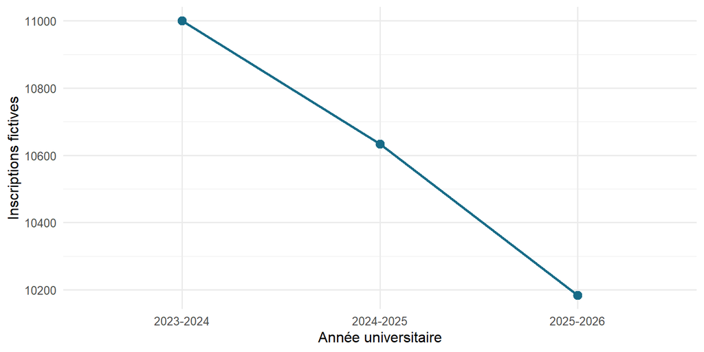

Inscriptions annuelles dans la population simulée

L’évolution des inscriptions résulte des entrées, poursuites et sorties définies par le simulateur. Elle ne mesure aucune évolution démographique de l’UPEC. Les résultats de réussite et de parcours doivent être lus avec les exclusions et la couverture, puis contextualisés par formation et niveau lorsque la granularité des données le permet. Les exports actuels des tableaux de bord sont agrégés : ils ne proposent pas de filtre par formation.

## 10 Indicateurs décisionnels

Le tableau distingue effectifs et pourcentages. « Non observable » correspond notamment aux transitions de fin de période ; cette valeur ne doit jamais être remplacée par zéro. Les indicateurs scolaires portent sur l’année d’inscription, ceux du devenir sur le millésime du diplôme et son type.

Répertoire des dix indicateurs

|  | Identifiant | Indicateur | Unité |
| --- | --- | --- | --- |
| 1 | I02 | Inscriptions principales | effectif |
| 4 | I03 | Validation annuelle parmi decisions connues | pourcentage |
| 7 | I05a | Passage annuel | pourcentage |
| 10 | I05c | Reorientation interne observee | pourcentage |
| 13 | I06 | Participation a l’evaluation | pourcentage |
| 16 | I07 | Satisfaction globale favorable | pourcentage |
| 19 | I08 | Attribution du diplome en niveau terminal | pourcentage |
| 22 | I09 | Situation connue a six mois | pourcentage |
| 26 | I10 | Emploi parmi repondants hors etudes | pourcentage |
| 30 | I11 | Poursuite d’etudes parmi situations connues | pourcentage |

Valeurs contrôlées : numérateurs, dénominateurs et statuts

| ID | Année | Diplôme | N | D | Valeur | Statut |
| --- | --- | --- | --- | --- | --- | --- |
| I02 | 2023-2024 | non_applicable | 11000 | Non disponible | 11000.00 | diffusable |
| I02 | 2024-2025 | non_applicable | 10633 | Non disponible | 10633.00 | diffusable |
| I02 | 2025-2026 | non_applicable | 10183 | Non disponible | 10183.00 | diffusable |
| I03 | 2023-2024 | non_applicable | 7179 | 10763 | 66.70 | diffusable |
| I03 | 2024-2025 | non_applicable | 6998 | 10403 | 67.27 | diffusable |
| I03 | 2025-2026 | non_applicable | 6654 | 9987 | 66.63 | diffusable |
| I05a | 2023-2024 | non_applicable | 4469 | 11000 | 40.63 | diffusable |
| I05a | 2024-2025 | non_applicable | 4192 | 10633 | 39.42 | diffusable |
| I05a | 2025-2026 | non_applicable | Non disponible | Non disponible | Non disponible | non_observable |
| I05c | 2023-2024 | non_applicable | 732 | 11000 | 6.65 | diffusable |
| I05c | 2024-2025 | non_applicable | 733 | 10633 | 6.89 | diffusable |
| I05c | 2025-2026 | non_applicable | Non disponible | Non disponible | Non disponible | non_observable |
| I06 | 2023-2024 | non_applicable | 6470 | 11000 | 58.82 | diffusable |
| I06 | 2024-2025 | non_applicable | 6171 | 10633 | 58.04 | diffusable |
| I06 | 2025-2026 | non_applicable | 5990 | 10183 | 58.82 | diffusable |
| I07 | 2023-2024 | non_applicable | 3527 | 5967 | 59.11 | diffusable |
| I07 | 2024-2025 | non_applicable | 3406 | 5672 | 60.05 | diffusable |
| I07 | 2025-2026 | non_applicable | 3324 | 5541 | 59.99 | diffusable |
| I08 | 2023-2024 | non_applicable | 2216 | 2933 | 75.55 | diffusable |
| I08 | 2024-2025 | non_applicable | 2285 | 2970 | 76.94 | diffusable |
| I08 | 2025-2026 | non_applicable | 2334 | 3012 | 77.49 | diffusable |
| I09 | 2023-2024 | licence | 900 | 1455 | 61.86 | diffusable |
| I09 | 2023-2024 | master | 449 | 761 | 59.00 | diffusable |
| I09 | 2024-2025 | licence | 864 | 1410 | 61.28 | diffusable |
| I09 | 2024-2025 | master | 545 | 875 | 62.29 | diffusable |
| I10 | 2023-2024 | licence | 201 | 335 | 60.00 | diffusable |
| I10 | 2023-2024 | master | 287 | 405 | 70.86 | diffusable |
| I10 | 2024-2025 | licence | 219 | 341 | 64.22 | diffusable |
| I10 | 2024-2025 | master | 362 | 492 | 73.58 | diffusable |
| I11 | 2023-2024 | licence | 565 | 900 | 62.78 | diffusable |
| I11 | 2023-2024 | master | 44 | 449 | 9.80 | diffusable |
| I11 | 2024-2025 | licence | 523 | 864 | 60.53 | diffusable |
| I11 | 2024-2025 | master | 53 | 545 | 9.72 | diffusable |

Les exclusions, les valeurs manquantes, la couverture et la population de référence restent disponibles dans le CSV complet `indicateurs.csv` du pipeline. Leur consultation accompagne toute réutilisation de ces taux.

## 11 Recommandations de pilotage

Les propositions suivantes illustrent une démarche professionnelle. Leur application réelle nécessiterait des données réelles autorisées, des échanges avec les équipes et une validation institutionnelle.

### 11.1 C01 — Volumes et capacites d’accueil

**Périmètre :** 2025-2026

**Résultat :** 10 183 inscriptions ; variation annuelle de -450 inscriptions (-4,23 %).

**Interprétation :** La variation combine entrees, sorties et progression du panel ; elle ne mesure pas seule l’attractivite.

**Implication métier :** Une evolution du volume peut modifier les besoins de capacite, mais sa composition doit etre examinee.

**Recommandation :** Ventiler les volumes par formation et niveau avant de formuler une hypothese sur les capacites ou l’attractivite.

### 11.2 C02 — Reussite et couverture des decisions

**Périmètre :** 2025-2026

**Résultat :** 66,63 % de validations : 6 654/9 987 decisions connues ; couverture 98,08 %, avec 196 decisions inconnues.

**Interprétation :** Le taux porte sur les decisions connues ; les inconnus ne sont pas des echecs.

**Implication métier :** Des ecarts de composition ou de couverture peuvent modifier les comparaisons de reussite.

**Recommandation :** Lire ensemble validation, couverture et profils ; examiner les dossiers inconnus avant d’interpreter une evolution.

### 11.3 C03 — Transitions et limite d’observation

**Périmètre :** Depart 2024-2025

**Résultat :** Passage 39,42 %, redoublement 20,55 %, reorientation 6,89 % ; denominateur 10 633 inscriptions de depart. Les transitions 2025-2026 sont censurees.

**Interprétation :** Les sorties restent au denominateur ; la poursuite intercycle est distincte du passage et de la reorientation.

**Implication métier :** Le dernier millesime scolaire ne dispose pas encore d’une transition suivante dans ce panel.

**Recommandation :** Afficher le depart et l’arrivee observables ; garder les transitions finales absentes et distinguer sortie et abandon.

### 11.4 C04 — Cohortes comparees a duree egale

**Périmètre :** Presence a horizon 1 des cohortes L1 2023-2024 et 2024-2025

**Résultat :** 87,30 % (3 492/4 000) et 87,35 % (1 747/2 000).

**Interprétation :** La presence dans le champ est tres proche a un an ; une absence ne prouve pas un abandon definitif.

**Implication métier :** La cohorte 2025-2026 ne peut pas etre comparee a un an faute de suivi disponible.

**Recommandation :** Comparer les cohortes a horizon egal et rechercher d’autres sources pour qualifier les absences dans un dispositif reel.

### 11.5 C05 — Satisfaction et participation

**Périmètre :** Evaluation de 2025-2026

**Résultat :** Participation 58,82 % (5 990/10 183) ; satisfaction favorable 59,99 % (3 324/5 541 reponses valides), couverture numerique 54,41 %.

**Interprétation :** La satisfaction est celle des repondants valides, pas de tous les inscrits ; non-reponse et NC sont distincts.

**Implication métier :** La participation et la couverture des items doivent accompagner toute comparaison entre formations.

**Recommandation :** Examiner composition des repondants, accessibilite et calendrier ; tester les relances sans supposer qu’elles corrigent tout biais.

### 11.6 C06 — Diplome : une mesure terminale distincte

**Périmètre :** 2025-2026

**Résultat :** 77,49 % d’attributions : 2 334/3 012 decisions terminales connues ; couverture 98,30 %.

**Interprétation :** La population est limitee aux L3/M2 avec decision connue ; il ne s’agit pas d’une diplomation a trois ans des entrants.

**Implication métier :** Validation annuelle et attribution du diplome repondent a des questions differentes.

**Recommandation :** Conserver les deux definitions et examiner le type de diplome et les decisions inconnues avant de comparer les resultats.

### 11.7 C07 — Devenir : lire ensemble emploi, etudes et couverture

**Périmètre :** Diplomes 2024-2025 ; situation a six mois

**Résultat :** Emploi parmi situations connues hors etudes : licence 64,22 % (219/341), master 73,58 % (362/492). Etudes parmi situations connues : 60,53 % et 9,72 %. Couvertures : 61,28 % et 62,29 %.

**Interprétation :** Les champs emploi et etudes ont des denominateurs differents ; les distributions sont programmees dans la simulation.

**Implication métier :** Un taux d’emploi hors etudes ne peut etre lu comme le resultat de tous les diplomes ni comme un effet du diplome.

**Recommandation :** Presenter I09, I10 et I11 ensemble par type et cohorte, sans additionner les taux ; exclure les collectes non closes.

### 11.8 C08 — Modele exploratoire : usage limite

**Périmètre :** Validation interne sur la coupe 2023-2024

**Résultat :** AUC 0,593 ; Brier 0,2164 contre 0,2218 pour la reference constante ; 2 081 etudiants de test.

**Interprétation :** La discrimination est limitee et le gain predictif modeste ; la validation n’est ni temporelle ni externe.

**Implication métier :** Ces performances et les associations du modele n’etablissent aucun effet causal ni seuil de decision individuelle.

**Recommandation :** Reserver le modele a l’illustration methodologique ; definir l’usage et une validation adaptee avant toute application reelle.

## 12 Limites et précautions

Toutes les distributions, associations et trajectoires sont produites par un simulateur. Les différences ne constituent pas des constats sur une université réelle. L’intervalle d’un coefficient décrit l’incertitude du modèle ajusté, sans couvrir l’incertitude du choix du mécanisme de simulation.

La fenêtre de trois ans limite le suivi, les sorties sont observées seulement dans le champ et les enquêtes restent exposées à la non-réponse. La structure des niveaux et formations impose des restrictions aux comparaisons. L’étude `notebooks/09_analyse_causale.qmd` ne retient aucune identification causale crédible : aucun effet n’est fabriqué ou interprété comme causal.

Les interfaces Shiny et Power BI facilitent la lecture sans supprimer ces limites. Le modèle Power BI protège les agrégations ambiguës entre plusieurs millésimes ; la lecture des statuts et des dénominateurs reste nécessaire.

## 13 Reproductibilité et accès aux livrables

Exécuter les commandes suivantes depuis la racine du projet, dans une session R activant `.Rprofile`. `renv::restore()` restaure les versions du lockfile ; `renv::snapshot()` enregistre des dépendances modifiées après validation.

```r
renv::restore()
testthat::test_dir("tests/testthat", stop_on_failure = TRUE)
source("scripts/run_reports.R")
renv::status()
```

`scripts/run_reports.R` configure puis exécute le graphe `targets` complet, reconstruction et rapports consommateurs inclus. Les tâches de VS Code permettent également de le lancer. Les notebooks `00` à `11` documentent les étapes ; leurs fonctions métier sont centralisées dans `R/`.

Pour actualiser les exports des deux interfaces, exécuter `source("scripts/refresh_dashboards.R")`, puis **Actualiser** dans Power BI Desktop. Ouvrir `powerbi/Observatoire.pbip` pour le rapport à cinq pages. Lancer `source("scripts/run_shiny.R")` pour l’application locale Shiny. `docs/tableaux_de_bord.md` décrit les filtres, les mesures et les recettes réellement réalisées. L’actualisation locale est automatisée côté R ; aucune publication Power BI Service ni passerelle ou planification système n’est configurée.

Le présent document lit les résultats contrôlés sans relancer les analyses. Depuis PowerShell, avec R et Quarto accessibles, le rendre ainsi :

```powershell
quarto render docs/rapport_final.qmd --to html --output-dir ../outputs/rapport_final
```

Le format HTML embarque ses ressources. Un rendu PDF utilise la même source avec `--to pdf` et nécessite une installation LaTeX disposant de LuaLaTeX. Cette dépendance reste optionnelle.

Environnement du rendu

| Element | Valeur |
| --- | --- |
| R | R version 4.6.1 (2026-06-24 ucrt) |
| Quarto | 1.10.18 |
| Gel des données | 20726 |
| Rendu | 2026-10-19 23:23:36 CEST |

Empreintes des produits consommés

| Produit | MD5 |
| --- | --- |
| resultats.rds | 71a3a6fc0110550262c928ae41a56a29 |
| modele_reussite.rds | d63a072f00d0dbfac7ca65b339519248 |
| indicateurs.csv | c23e08e2d25008b5856fcb79404fe634 |
| constats.csv | 27ae3e69f6f8b7dcf874444c2420150f |
| synthese_pilotage.md | d2dbb908904b734a6bfb1b0fca8de99e |
| sources.csv | c94ee85de6670caf772ee30678de0a8c |

Les sources détaillées sont consignées dans le fichier `sources.csv` associé aux produits. Un nouveau rendu constitue une photographie d’un calcul donné ; une modification de source exige d’abord l’actualisation du pipeline.